# Estadísticas de COVID

Ana Karen Sotero Salazar, Oscar Gerardo Varela Flores, Alberto Lichi Bustamante

##La finalidad del presente trabajo es mostrar las estadísticas en tablas de datos y gráficas de los descensos, contagios y pruebas de COVID en México desde el 18 Marzo del 2020 al 2 de Enero del 2021 a través del uso de RStudio Cloud

##Como primer paso para la realización del siguiente trabajo se instalaron las siguientes librerías:

```r
library(readxl)
library(ggplot2)
library(plotly)
```

## A continuación describiremos para que usaremos cada una:

## - librery(readxl) La usamos para leer archivos importados de Excel

## - library(ggplot2) La usamos para la realización de gráficas más atractivas visualmente.

## - library(plotly) Esta librería es una forma sencilla de realizar gráficas.

##Para empezar a trabajar con los datos de Excel, tuvimos que subir los archivos a RStudio Cloud, y utilizar nuestra función de read_excel para poder trabajar con ellos.

```r
CasosCOVID <- read_excel("CasosCOVID.xlsx")
MuertesCOVID<- read_excel("MuertesCOVID.xlsx")
PruebasCOVID<-read_excel("PruebasCOVID.xlsx")
```

## Para visualizar la tabla de datos que vienen en los archivos de Excel en un Chunk agregamos el nombre de nuestro archivo

```r
CasosCOVID
```

```
## # A tibble: 291 x 2
##    Fecha               `N. de casos`
##    <dttm>                      <dbl>
##  1 2020-03-18 00:00:00            25
##  2 2020-03-19 00:00:00            46
##  3 2020-03-20 00:00:00            39
##  4 2020-03-21 00:00:00            48
##  5 2020-03-22 00:00:00            51
##  6 2020-03-23 00:00:00            38
##  7 2020-03-24 00:00:00            70
##  8 2020-03-25 00:00:00           110
##  9 2020-03-26 00:00:00           132
## 10 2020-03-27 00:00:00           131
## # … with 281 more rows
```

```r
MuertesCOVID
```

```
## # A tibble: 291 x 2
##    Fecha               `N. de muertes`
##    <dttm>                        <dbl>
##  1 2020-03-18 00:00:00               0
##  2 2020-03-19 00:00:00               1
##  3 2020-03-20 00:00:00               1
##  4 2020-03-21 00:00:00               0
##  5 2020-03-22 00:00:00               1
##  6 2020-03-23 00:00:00               1
##  7 2020-03-24 00:00:00               1
##  8 2020-03-25 00:00:00               1
##  9 2020-03-26 00:00:00               1
## 10 2020-03-27 00:00:00               4
## # … with 281 more rows
```

```r
PruebasCOVID
```

```
## # A tibble: 291 x 2
##    Fecha               `N. de pruebas realizadas`
##    <dttm>                                   <dbl>
##  1 2020-03-18 00:00:00                        773
##  2 2020-03-19 00:00:00                        842
##  3 2020-03-20 00:00:00                        760
##  4 2020-03-21 00:00:00                        490
##  5 2020-03-22 00:00:00                        410
##  6 2020-03-23 00:00:00                       1082
##  7 2020-03-24 00:00:00                       1374
##  8 2020-03-25 00:00:00                       1430
##  9 2020-03-26 00:00:00                       1372
## 10 2020-03-27 00:00:00                       1596
## # … with 281 more rows
```

## Una vez realizado los pasos anteriores continuaremos con la elaboración de las gráficas.

## Para loa primeros ejemplos usaremos la función plot, que son gráficas sencillas y entre paréntesis pondremos el nombre de cada uno de nuestros datos.

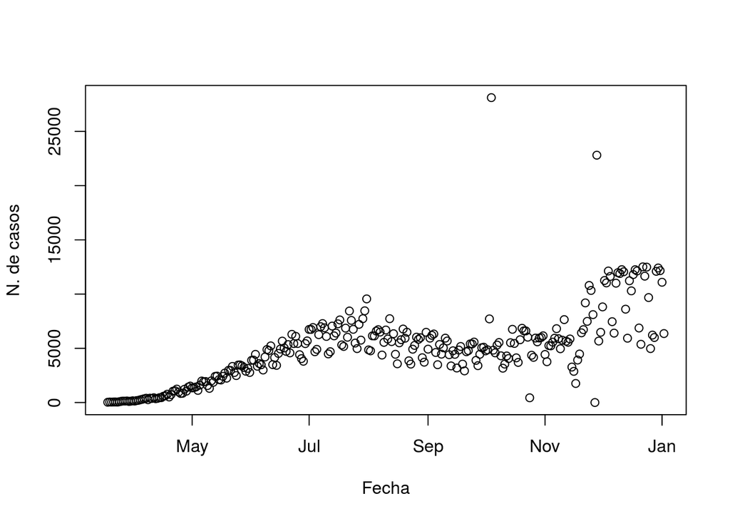

```r
plot(CasosCOVID, type="p")
```

## En caso de que queramos cambiar la presentación de la gráfica utilizaremos la función type=l, como se muestra a continuación

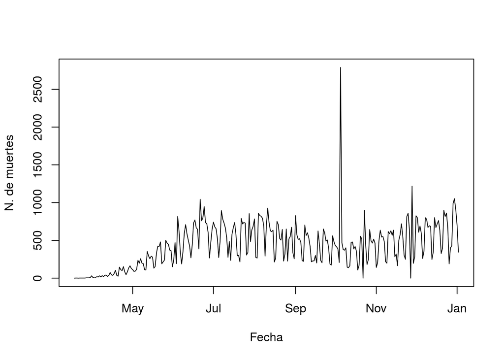

```r
plot(MuertesCOVID, type="l")
```

##También podemos usar la siguiente presentación type=”o”

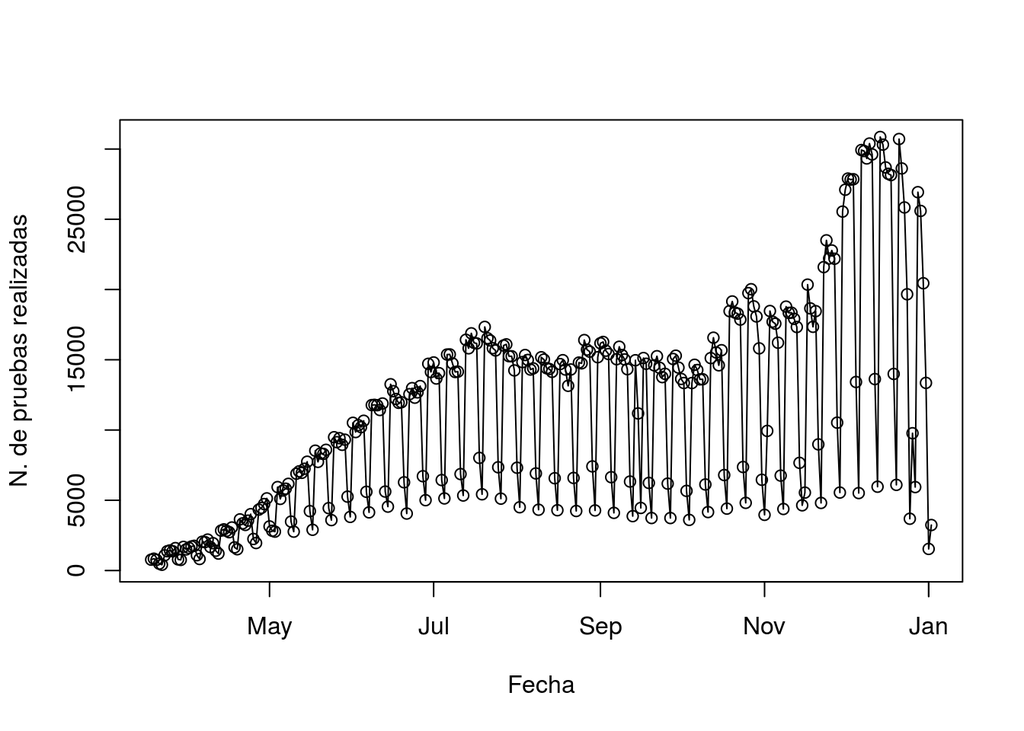

```r
plot(PruebasCOVID, type="o")
```

## Otra forma de realizar las gráficas de una manera más atractiva visualmente es con la siguiente función: ggplot2.

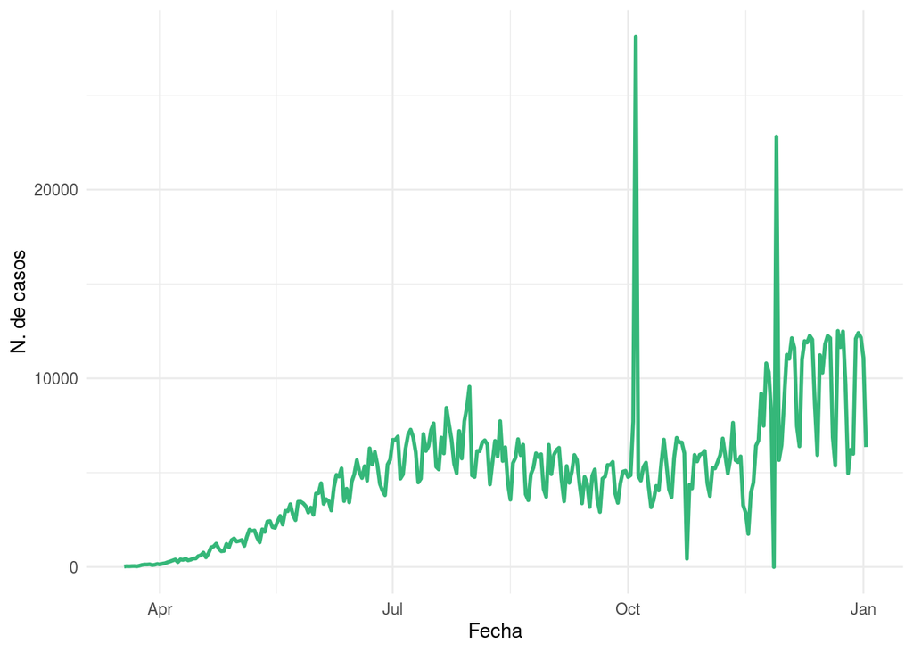

```r
ggplot(CasosCOVID) +
 aes(x = Fecha, y = `N. de casos`) +
 geom_line(size = 1L, colour = "#35b779") +
 theme_minimal()
```

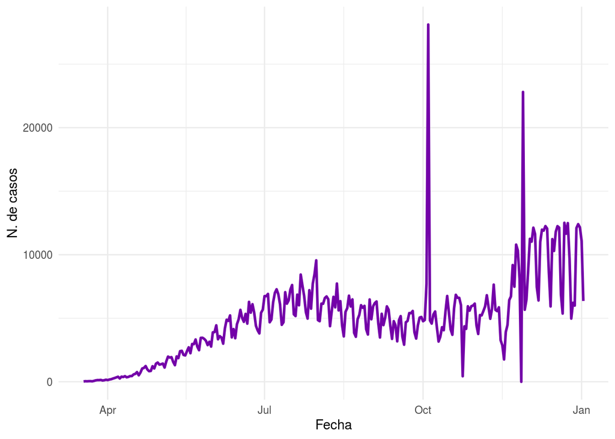

```r
ggplot(CasosCOVID) +
 aes(x = Fecha, y = `N. de casos`) +
 geom_line(size = 1L, colour = "#7301a8") +
 theme_minimal()
```

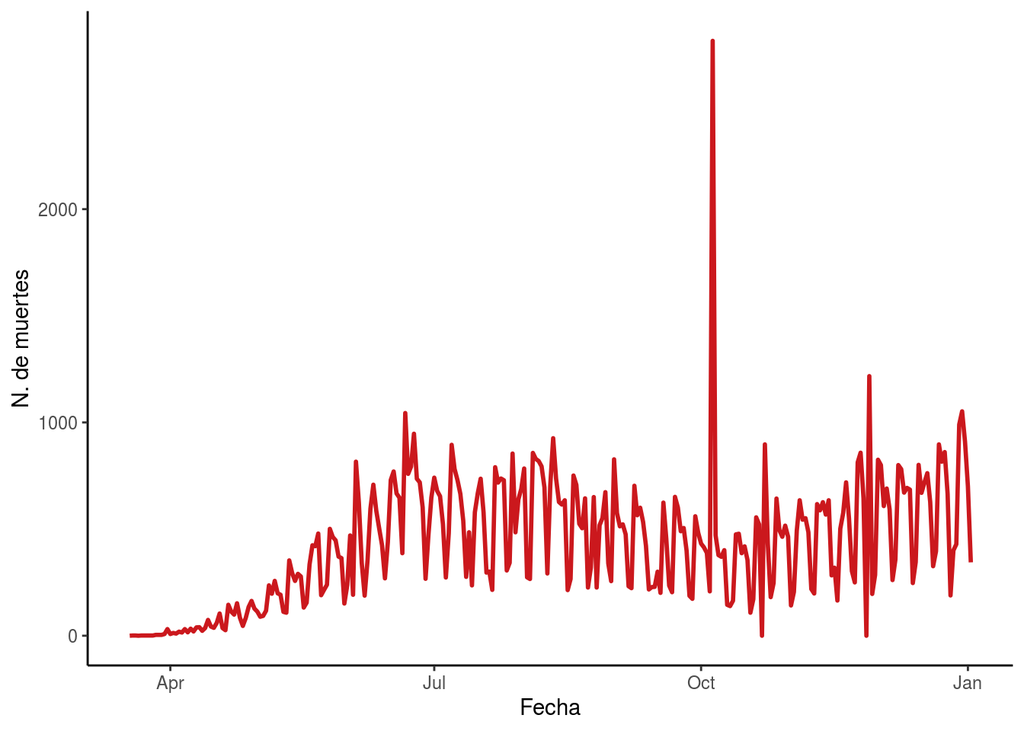

```r
ggplot(MuertesCOVID) +
 aes(x = Fecha, y = `N. de muertes`) +
 geom_line(size = 1L, colour = "#cb181d") +
 theme_classic()
```

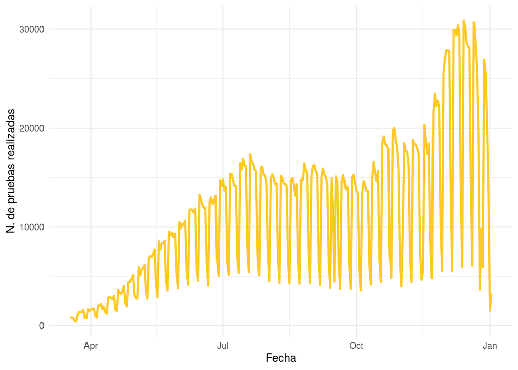

```r
ggplot(PruebasCOVID) +
 aes(x = Fecha, y = `N. de pruebas realizadas`) +
 geom_line(size = 1L, colour = "#fdc926") +
 theme_minimal()
```

## La finalidad de este trabajo fue mostrar el comportamiento que ha tenido el COVID en México desde su llegada en el 2020 hasta la actualidad, para concientizar la gravedad y el efecto que ha tenido este virus en nuestra población, los datos estadísticos son reales y verídicos. En el siguiente apartado se adjunta un video con el resumen del año anterior sobre el COVID.

[video not shown]

# ¡Por favor, quédese en casa!

## Y tome las medidas de sanidad necesarias

[video not shown]